# FullCode_Bank Churn Prediction

### Neural Network with Adam Optimizer and Dropout

```python
backend.clear_session()
#Fixing the seed for random number generators so that we can ensure we receive the same output everytime
np.random.seed(2)
random.seed(2)
tf.random.set_seed(2)
```

```python
#Initializing the neural network
model_2 = Sequential()
#Adding the input layer with 32 neurons and relu as activation function
model_2.add(Dense(32,activation='relu',input_dim = X_train.shape[1]))
model_2.add(Dropout(0.2))
model_2.add(Dense(16,activation='relu'))
model_2.add(Dense(8,activation='relu'))
model_2.add(Dropout(0.1))
model_2.add(Dense(4,activation='relu'))
model_2.add(Dense(1, activation = 'sigmoid'))
```

```python
optimizer = tf.keras.optimizers.Adam()
```

```python
metric = keras.metrics.Recall()
```

```python
model_2.compile(loss='binary_crossentropy',optimizer=optimizer,metrics=[metric])
```

```python
# Summary of the model
model_2.summary()
```

```
Model: "sequential"
```

```
┏━━━━━━━━━━━━━━━━━━━━━━━━━━━━━━━━━━━━━━┳━━━━━━━━━━━━━━━━━━━━━━━━━━━━━┳━━━━━━━━━━━━━━━━━┓
┃ Layer (type)                         ┃ Output Shape                ┃         Param # ┃
┡━━━━━━━━━━━━━━━━━━━━━━━━━━━━━━━━━━━━━━╇━━━━━━━━━━━━━━━━━━━━━━━━━━━━━╇━━━━━━━━━━━━━━━━━┩
│ dense (Dense)                        │ (None, 32)                  │             384 │
├──────────────────────────────────────┼─────────────────────────────┼─────────────────┤
│ dropout (Dropout)                    │ (None, 32)                  │               0 │
├──────────────────────────────────────┼─────────────────────────────┼─────────────────┤
│ dense_1 (Dense)                      │ (None, 16)                  │             528 │
├──────────────────────────────────────┼─────────────────────────────┼─────────────────┤
│ dense_2 (Dense)                      │ (None, 8)                   │             136 │
├──────────────────────────────────────┼─────────────────────────────┼─────────────────┤
│ dropout_1 (Dropout)                  │ (None, 8)                   │               0 │
├──────────────────────────────────────┼─────────────────────────────┼─────────────────┤
│ dense_3 (Dense)                      │ (None, 4)                   │              36 │
├──────────────────────────────────────┼─────────────────────────────┼─────────────────┤
│ dense_4 (Dense)                      │ (None, 1)                   │               5 │
└──────────────────────────────────────┴─────────────────────────────┴─────────────────┘
```

```
 Total params: 1,089 (4.25 KB)
```

```
 Trainable params: 1,089 (4.25 KB)
```

```
 Non-trainable params: 0 (0.00 B)
```

```python
#Fitting the ANN with batch_size = 32 and 100 epochs
history_2 = model_2.fit(
    X_train,y_train,
    batch_size=32,  ##Complete the code to specify the batch size.
    epochs=100, ##Complete the code to specify the # of epochs.
    verbose=1,
    validation_data=(X_val,y_val)
)
```

```
188/188 ━━━━━━━━━━━━━━━━━━━━ 3s 5ms/step - loss: 0.5601 - recall: 0.0442 - val_loss: 0.4496 - val_recall: 0.0049
188/188 ━━━━━━━━━━━━━━━━━━━━ 1s 3ms/step - loss: 0.4417 - recall: 0.0247 - val_loss: 0.4293 - val_recall: 0.1450
188/188 ━━━━━━━━━━━━━━━━━━━━ 1s 3ms/step - loss: 0.4269 - recall: 0.1072 - val_loss: 0.4186 - val_recall: 0.1695
188/188 ━━━━━━━━━━━━━━━━━━━━ 1s 3ms/step - loss: 0.4139 - recall: 0.1558 - val_loss: 0.4051 - val_recall: 0.2875
188/188 ━━━━━━━━━━━━━━━━━━━━ 1s 3ms/step - loss: 0.3925 - recall: 0.2834 - val_loss: 0.3849 - val_recall: 0.3391
188/188 ━━━━━━━━━━━━━━━━━━━━ 1s 3ms/step - loss: 0.3795 - recall: 0.3230 - val_loss: 0.3727 - val_recall: 0.3833
188/188 ━━━━━━━━━━━━━━━━━━━━ 1s 3ms/step - loss: 0.3675 - recall: 0.3572 - val_loss: 0.3651 - val_recall: 0.4201
188/188 ━━━━━━━━━━━━━━━━━━━━ 1s 3ms/step - loss: 0.3629 - recall: 0.3710 - val_loss: 0.3618 - val_recall: 0.4226
188/188 ━━━━━━━━━━━━━━━━━━━━ 1s 3ms/step - loss: 0.3554 - recall: 0.4262 - val_loss: 0.3605 - val_recall: 0.4324
188/188 ━━━━━━━━━━━━━━━━━━━━ 1s 4ms/step - loss: 0.3560 - recall: 0.4140 - val_loss: 0.3587 - val_recall: 0.4079
188/188 ━━━━━━━━━━━━━━━━━━━━ 2s 6ms/step - loss: 0.3536 - recall: 0.4279 - val_loss: 0.3551 - val_recall: 0.4324
188/188 ━━━━━━━━━━━━━━━━━━━━ 1s 6ms/step - loss: 0.3489 - recall: 0.4385 - val_loss: 0.3572 - val_recall: 0.4029
188/188 ━━━━━━━━━━━━━━━━━━━━ 1s 3ms/step - loss: 0.3464 - recall: 0.4142 - val_loss: 0.3552 - val_recall: 0.4423
188/188 ━━━━━━━━━━━━━━━━━━━━ 1s 3ms/step - loss: 0.3376 - recall: 0.4647 - val_loss: 0.3527 - val_recall: 0.4496
188/188 ━━━━━━━━━━━━━━━━━━━━ 1s 3ms/step - loss: 0.3403 - recall: 0.4488 - val_loss: 0.3516 - val_recall: 0.4595
188/188 ━━━━━━━━━━━━━━━━━━━━ 1s 3ms/step - loss: 0.3389 - recall: 0.4562 - val_loss: 0.3511 - val_recall: 0.4373
188/188 ━━━━━━━━━━━━━━━━━━━━ 1s 3ms/step - loss: 0.3376 - recall: 0.4550 - val_loss: 0.3527 - val_recall: 0.4545
188/188 ━━━━━━━━━━━━━━━━━━━━ 1s 3ms/step - loss: 0.3394 - recall: 0.4485 - val_loss: 0.3521 - val_recall: 0.4619
188/188 ━━━━━━━━━━━━━━━━━━━━ 1s 3ms/step - loss: 0.3261 - recall: 0.4761 - val_loss: 0.3513 - val_recall: 0.4767
188/188 ━━━━━━━━━━━━━━━━━━━━ 1s 3ms/step - loss: 0.3311 - recall: 0.4695 - val_loss: 0.3551 - val_recall: 0.4349
188/188 ━━━━━━━━━━━━━━━━━━━━ 1s 3ms/step - loss: 0.3339 - recall: 0.4522 - val_loss: 0.3529 - val_recall: 0.4767
188/188 ━━━━━━━━━━━━━━━━━━━━ 1s 3ms/step - loss: 0.3300 - recall: 0.4795 - val_loss: 0.3508 - val_recall: 0.4693
188/188 ━━━━━━━━━━━━━━━━━━━━ 2s 5ms/step - loss: 0.3309 - recall: 0.4685 - val_loss: 0.3505 - val_recall: 0.4619
188/188 ━━━━━━━━━━━━━━━━━━━━ 1s 6ms/step - loss: 0.3270 - recall: 0.4568 - val_loss: 0.3520 - val_recall: 0.4693
188/188 ━━━━━━━━━━━━━━━━━━━━ 1s 5ms/step - loss: 0.3338 - recall: 0.4744 - val_loss: 0.3515 - val_recall: 0.4595
188/188 ━━━━━━━━━━━━━━━━━━━━ 1s 3ms/step - loss: 0.3288 - recall: 0.4686 - val_loss: 0.3509 - val_recall: 0.4717
188/188 ━━━━━━━━━━━━━━━━━━━━ 1s 3ms/step - loss: 0.3280 - recall: 0.4692 - val_loss: 0.3502 - val_recall: 0.4644
188/188 ━━━━━━━━━━━━━━━━━━━━ 1s 3ms/step - loss: 0.3222 - recall: 0.4679 - val_loss: 0.3520 - val_recall: 0.4545
188/188 ━━━━━━━━━━━━━━━━━━━━ 1s 3ms/step - loss: 0.3239 - recall: 0.4771 - val_loss: 0.3508 - val_recall: 0.4668
188/188 ━━━━━━━━━━━━━━━━━━━━ 1s 3ms/step - loss: 0.3238 - recall: 0.4810 - val_loss: 0.3510 - val_recall: 0.4914
188/188 ━━━━━━━━━━━━━━━━━━━━ 1s 3ms/step - loss: 0.3276 - recall: 0.4963 - val_loss: 0.3520 - val_recall: 0.4889
188/188 ━━━━━━━━━━━━━━━━━━━━ 1s 3ms/step - loss: 0.3277 - recall: 0.4668 - val_loss: 0.3519 - val_recall: 0.4545
188/188 ━━━━━━━━━━━━━━━━━━━━ 1s 3ms/step - loss: 0.3228 - recall: 0.4798 - val_loss: 0.3511 - val_recall: 0.4791
188/188 ━━━━━━━━━━━━━━━━━━━━ 1s 3ms/step - loss: 0.3233 - recall: 0.4712 - val_loss: 0.3510 - val_recall: 0.4570
188/188 ━━━━━━━━━━━━━━━━━━━━ 1s 3ms/step - loss: 0.3247 - recall: 0.4734 - val_loss: 0.3504 - val_recall: 0.4570
188/188 ━━━━━━━━━━━━━━━━━━━━ 2s 6ms/step - loss: 0.3199 - recall: 0.4972 - val_loss: 0.3515 - val_recall: 0.4963
188/188 ━━━━━━━━━━━━━━━━━━━━ 1s 5ms/step - loss: 0.3173 - recall: 0.5104 - val_loss: 0.3511 - val_recall: 0.5061
188/188 ━━━━━━━━━━━━━━━━━━━━ 1s 4ms/step - loss: 0.3157 - recall: 0.4965 - val_loss: 0.3504 - val_recall: 0.4816
188/188 ━━━━━━━━━━━━━━━━━━━━ 1s 3ms/step - loss: 0.3162 - recall: 0.4857 - val_loss: 0.3503 - val_recall: 0.4717
188/188 ━━━━━━━━━━━━━━━━━━━━ 1s 4ms/step - loss: 0.3211 - recall: 0.4754 - val_loss: 0.3498 - val_recall: 0.4791
```

[output cut: 45 more lines]

```
188/188 ━━━━━━━━━━━━━━━━━━━━ 1s 3ms/step - loss: 0.3079 - recall: 0.5062 - val_loss: 0.3493 - val_recall: 0.4619
188/188 ━━━━━━━━━━━━━━━━━━━━ 1s 3ms/step - loss: 0.3052 - recall: 0.4921 - val_loss: 0.3517 - val_recall: 0.4791
188/188 ━━━━━━━━━━━━━━━━━━━━ 1s 3ms/step - loss: 0.3055 - recall: 0.5097 - val_loss: 0.3526 - val_recall: 0.4816
188/188 ━━━━━━━━━━━━━━━━━━━━ 1s 3ms/step - loss: 0.3090 - recall: 0.5143 - val_loss: 0.3504 - val_recall: 0.4816
188/188 ━━━━━━━━━━━━━━━━━━━━ 1s 4ms/step - loss: 0.3083 - recall: 0.4903 - val_loss: 0.3517 - val_recall: 0.4939
188/188 ━━━━━━━━━━━━━━━━━━━━ 1s 6ms/step - loss: 0.3065 - recall: 0.5208 - val_loss: 0.3502 - val_recall: 0.4767
188/188 ━━━━━━━━━━━━━━━━━━━━ 1s 6ms/step - loss: 0.3054 - recall: 0.5117 - val_loss: 0.3506 - val_recall: 0.4939
188/188 ━━━━━━━━━━━━━━━━━━━━ 1s 5ms/step - loss: 0.3074 - recall: 0.5260 - val_loss: 0.3511 - val_recall: 0.4988
188/188 ━━━━━━━━━━━━━━━━━━━━ 1s 3ms/step - loss: 0.3100 - recall: 0.5021 - val_loss: 0.3490 - val_recall: 0.4816
188/188 ━━━━━━━━━━━━━━━━━━━━ 1s 3ms/step - loss: 0.3061 - recall: 0.4955 - val_loss: 0.3495 - val_recall: 0.4767
188/188 ━━━━━━━━━━━━━━━━━━━━ 1s 3ms/step - loss: 0.3049 - recall: 0.5200 - val_loss: 0.3509 - val_recall: 0.4668
188/188 ━━━━━━━━━━━━━━━━━━━━ 1s 3ms/step - loss: 0.3026 - recall: 0.4961 - val_loss: 0.3500 - val_recall: 0.4889
188/188 ━━━━━━━━━━━━━━━━━━━━ 1s 3ms/step - loss: 0.3058 - recall: 0.5157 - val_loss: 0.3524 - val_recall: 0.4840
188/188 ━━━━━━━━━━━━━━━━━━━━ 1s 3ms/step - loss: 0.3068 - recall: 0.5127 - val_loss: 0.3506 - val_recall: 0.4988
188/188 ━━━━━━━━━━━━━━━━━━━━ 1s 3ms/step - loss: 0.3103 - recall: 0.5106 - val_loss: 0.3522 - val_recall: 0.4816
```

**Loss function**

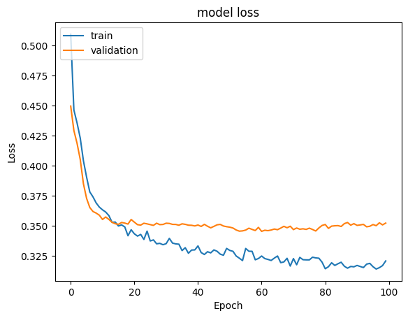

```python
#Plotting Train Loss vs Validation Loss
plt.plot(history_2.history['loss'])
plt.plot(history_2.history['val_loss'])
plt.title('model loss')
plt.ylabel('Loss')
plt.xlabel('Epoch')
plt.legend(['train', 'validation'], loc='upper left')
plt.show()
```

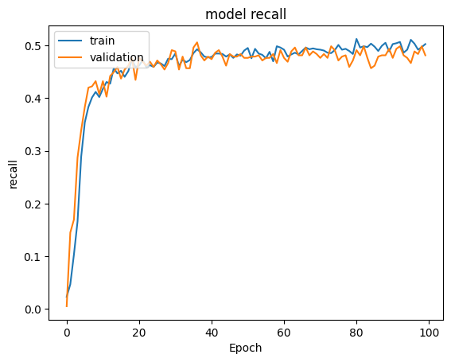

```python
#Plotting Train recall vs Validation recall
plt.plot(history_2.history['recall'])
plt.plot(history_2.history['val_recall'])
plt.title('model recall')
plt.ylabel('recall')
plt.xlabel('Epoch')
plt.legend(['train', 'validation'], loc='upper left')
plt.show()
```

```python
#Predicting the results using best as a threshold
y_train_pred = model_2.predict(X_train)
y_train_pred = (y_train_pred > 0.5)
y_train_pred
```

```
188/188 ━━━━━━━━━━━━━━━━━━━━ 0s 2ms/step
```

```
array([[False],
       [False],
       [ True],
       ...,
       [ True],
       [False],
       [ True]])
```

```python
#Predicting the results using 0.5 as the threshold.
y_val_pred = model_2.predict(X_val)
y_val_pred = (y_val_pred > 0.5)
y_val_pred
```

```
63/63 ━━━━━━━━━━━━━━━━━━━━ 0s 1ms/step
```

```
array([[False],
       [False],
       [False],
       ...,
       [False],
       [False],
       [False]])
```

```python
model_name = "NN with Adam & Dropout"

train_metric_df.loc[model_name] = recall_score(y_train,y_train_pred)
valid_metric_df.loc[model_name] = recall_score(y_val,y_val_pred)
```

```python
#classification report
cr=classification_report(y_train,y_train_pred)
print(cr)
```

```
              precision    recall  f1-score   support

         0.0       0.89      0.97      0.93      4777
         1.0       0.81      0.55      0.66      1223

    accuracy                           0.88      6000
   macro avg       0.85      0.76      0.79      6000
weighted avg       0.88      0.88      0.87      6000
```

```python
#classification report
cr = classification_report(y_val,y_val_pred) ## Complete the code to check the model's performance on the validation set
print(cr)
```

```
              precision    recall  f1-score   support

         0.0       0.88      0.95      0.91      1593
         1.0       0.70      0.48      0.57       407

    accuracy                           0.85      2000
   macro avg       0.79      0.71      0.74      2000
weighted avg       0.84      0.85      0.84      2000
```

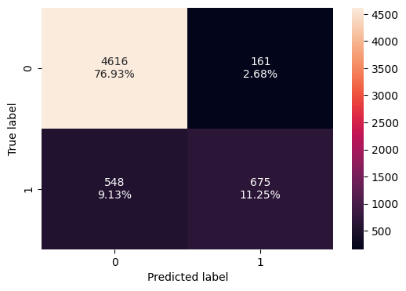

```python
#Calculating the confusion matrix
make_confusion_matrix(y_train, y_train_pred)
```

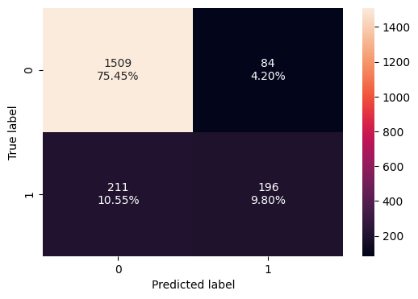

```python
#Calculating the confusion matrix
make_confusion_matrix(y_val,y_val_pred)  ## Complete the code to check the model's performance on the validation set
```

**Observation**

- Model's performance across training validation set seems to be at par.
- Reducing the neurons and also adding dropout actually helped in reducing overfitting.

### Neural Network with Balanced Data (by applying SMOTE) and SGD Optimizer

It is observed that the model's had tendency of overfitting. One of the main reason for that is imbalanced data. Trying SMOTE to reduce the imbalance.

```python
sm  = SMOTE(random_state=42)
X_train_smote, y_train_smote= sm.fit_resample(X_train, y_train)
print('After UpSampling, the shape of train_X: {}'.format(X_train_smote.shape))
print('After UpSampling, the shape of train_y: {} \n'.format(y_train_smote.shape))
```

```
After UpSampling, the shape of train_X: (9554, 11)
After UpSampling, the shape of train_y: (9554,)
```

```python
backend.clear_session()
#Fixing the seed for random number generators so that we can ensure we receive the same output everytime
np.random.seed(2)
random.seed(2)
tf.random.set_seed(2)
```

```python
#Initializing the model
model_3 = Sequential()
model_3.add(Dense(32,activation='relu',input_dim = X_train_smote.shape[1]))
model_3.add(Dense(16,activation='relu'))
model_3.add(Dense(8,activation='relu'))
model_3.add(Dense(1, activation = 'sigmoid'))
```

```python
#using SGD as the optimizer.
optimizer = tf.keras.optimizers.SGD(0.001)

metric = keras.metrics.Recall()
```

```python
model_3.compile(loss='binary_crossentropy',optimizer=optimizer,metrics=[metric])
```

```python
model_3.summary()
```

```
Model: "sequential"
```

```
┏━━━━━━━━━━━━━━━━━━━━━━━━━━━━━━━━━━━━━━┳━━━━━━━━━━━━━━━━━━━━━━━━━━━━━┳━━━━━━━━━━━━━━━━━┓
┃ Layer (type)                         ┃ Output Shape                ┃         Param # ┃
┡━━━━━━━━━━━━━━━━━━━━━━━━━━━━━━━━━━━━━━╇━━━━━━━━━━━━━━━━━━━━━━━━━━━━━╇━━━━━━━━━━━━━━━━━┩
│ dense (Dense)                        │ (None, 32)                  │             384 │
├──────────────────────────────────────┼─────────────────────────────┼─────────────────┤
│ dense_1 (Dense)                      │ (None, 16)                  │             528 │
├──────────────────────────────────────┼─────────────────────────────┼─────────────────┤
│ dense_2 (Dense)                      │ (None, 8)                   │             136 │
├──────────────────────────────────────┼─────────────────────────────┼─────────────────┤
│ dense_3 (Dense)                      │ (None, 1)                   │               9 │
└──────────────────────────────────────┴─────────────────────────────┴─────────────────┘
```

```
 Total params: 1,057 (4.13 KB)
```

```
 Trainable params: 1,057 (4.13 KB)
```

```
 Non-trainable params: 0 (0.00 B)
```

```python
#Fitting the ANN
history_3 = model_3.fit(
    X_train_smote, y_train_smote,
    batch_size=32,
    epochs=50,
    verbose=1,
    validation_data = (X_val,y_val)
)
```

```
299/299 ━━━━━━━━━━━━━━━━━━━━ 3s 6ms/step - loss: 0.7003 - recall: 0.8153 - val_loss: 0.7150 - val_recall: 0.7862
299/299 ━━━━━━━━━━━━━━━━━━━━ 1s 4ms/step - loss: 0.6968 - recall: 0.7907 - val_loss: 0.7074 - val_recall: 0.7592
299/299 ━━━━━━━━━━━━━━━━━━━━ 1s 4ms/step - loss: 0.6934 - recall: 0.7676 - val_loss: 0.6998 - val_recall: 0.7248
299/299 ━━━━━━━━━━━━━━━━━━━━ 2s 2ms/step - loss: 0.6899 - recall: 0.7369 - val_loss: 0.6919 - val_recall: 0.6806
299/299 ━━━━━━━━━━━━━━━━━━━━ 1s 2ms/step - loss: 0.6860 - recall: 0.7068 - val_loss: 0.6840 - val_recall: 0.6364
299/299 ━━━━━━━━━━━━━━━━━━━━ 1s 4ms/step - loss: 0.6820 - recall: 0.6771 - val_loss: 0.6764 - val_recall: 0.6216
299/299 ━━━━━━━━━━━━━━━━━━━━ 1s 4ms/step - loss: 0.6782 - recall: 0.6557 - val_loss: 0.6695 - val_recall: 0.6069
299/299 ━━━━━━━━━━━━━━━━━━━━ 1s 4ms/step - loss: 0.6745 - recall: 0.6374 - val_loss: 0.6632 - val_recall: 0.5971
299/299 ━━━━━━━━━━━━━━━━━━━━ 1s 3ms/step - loss: 0.6710 - recall: 0.6353 - val_loss: 0.6574 - val_recall: 0.5897
299/299 ━━━━━━━━━━━━━━━━━━━━ 1s 2ms/step - loss: 0.6676 - recall: 0.6370 - val_loss: 0.6520 - val_recall: 0.5946
299/299 ━━━━━━━━━━━━━━━━━━━━ 1s 2ms/step - loss: 0.6644 - recall: 0.6374 - val_loss: 0.6468 - val_recall: 0.5872
299/299 ━━━━━━━━━━━━━━━━━━━━ 1s 2ms/step - loss: 0.6611 - recall: 0.6375 - val_loss: 0.6419 - val_recall: 0.5848
299/299 ━━━━━━━━━━━━━━━━━━━━ 1s 2ms/step - loss: 0.6578 - recall: 0.6410 - val_loss: 0.6371 - val_recall: 0.5749
299/299 ━━━━━━━━━━━━━━━━━━━━ 1s 2ms/step - loss: 0.6545 - recall: 0.6454 - val_loss: 0.6326 - val_recall: 0.5774
299/299 ━━━━━━━━━━━━━━━━━━━━ 1s 2ms/step - loss: 0.6512 - recall: 0.6496 - val_loss: 0.6284 - val_recall: 0.5799
299/299 ━━━━━━━━━━━━━━━━━━━━ 1s 2ms/step - loss: 0.6479 - recall: 0.6518 - val_loss: 0.6242 - val_recall: 0.5823
299/299 ━━━━━━━━━━━━━━━━━━━━ 1s 3ms/step - loss: 0.6446 - recall: 0.6564 - val_loss: 0.6202 - val_recall: 0.5848
299/299 ━━━━━━━━━━━━━━━━━━━━ 1s 4ms/step - loss: 0.6411 - recall: 0.6620 - val_loss: 0.6164 - val_recall: 0.5971
299/299 ━━━━━━━━━━━━━━━━━━━━ 2s 2ms/step - loss: 0.6377 - recall: 0.6661 - val_loss: 0.6129 - val_recall: 0.5995
299/299 ━━━━━━━━━━━━━━━━━━━━ 1s 2ms/step - loss: 0.6342 - recall: 0.6706 - val_loss: 0.6095 - val_recall: 0.6020
299/299 ━━━━━━━━━━━━━━━━━━━━ 1s 2ms/step - loss: 0.6306 - recall: 0.6735 - val_loss: 0.6062 - val_recall: 0.6069
299/299 ━━━━━━━━━━━━━━━━━━━━ 1s 2ms/step - loss: 0.6270 - recall: 0.6775 - val_loss: 0.6030 - val_recall: 0.6118
299/299 ━━━━━━━━━━━━━━━━━━━━ 1s 2ms/step - loss: 0.6234 - recall: 0.6852 - val_loss: 0.5999 - val_recall: 0.6167
299/299 ━━━━━━━━━━━━━━━━━━━━ 1s 2ms/step - loss: 0.6197 - recall: 0.6911 - val_loss: 0.5970 - val_recall: 0.6167
299/299 ━━━━━━━━━━━━━━━━━━━━ 1s 2ms/step - loss: 0.6160 - recall: 0.6962 - val_loss: 0.5942 - val_recall: 0.6241
299/299 ━━━━━━━━━━━━━━━━━━━━ 1s 2ms/step - loss: 0.6122 - recall: 0.6978 - val_loss: 0.5916 - val_recall: 0.6265
299/299 ━━━━━━━━━━━━━━━━━━━━ 1s 2ms/step - loss: 0.6085 - recall: 0.7050 - val_loss: 0.5890 - val_recall: 0.6241
299/299 ━━━━━━━━━━━━━━━━━━━━ 2s 4ms/step - loss: 0.6048 - recall: 0.7081 - val_loss: 0.5866 - val_recall: 0.6290
299/299 ━━━━━━━━━━━━━━━━━━━━ 2s 2ms/step - loss: 0.6011 - recall: 0.7141 - val_loss: 0.5841 - val_recall: 0.6314
299/299 ━━━━━━━━━━━━━━━━━━━━ 1s 2ms/step - loss: 0.5974 - recall: 0.7168 - val_loss: 0.5817 - val_recall: 0.6413
299/299 ━━━━━━━━━━━━━━━━━━━━ 1s 2ms/step - loss: 0.5937 - recall: 0.7192 - val_loss: 0.5794 - val_recall: 0.6437
299/299 ━━━━━━━━━━━━━━━━━━━━ 1s 2ms/step - loss: 0.5900 - recall: 0.7253 - val_loss: 0.5773 - val_recall: 0.6511
299/299 ━━━━━━━━━━━━━━━━━━━━ 1s 2ms/step - loss: 0.5864 - recall: 0.7277 - val_loss: 0.5753 - val_recall: 0.6560
299/299 ━━━━━━━━━━━━━━━━━━━━ 1s 2ms/step - loss: 0.5828 - recall: 0.7295 - val_loss: 0.5733 - val_recall: 0.6585
299/299 ━━━━━━━━━━━━━━━━━━━━ 1s 2ms/step - loss: 0.5793 - recall: 0.7330 - val_loss: 0.5712 - val_recall: 0.6658
299/299 ━━━━━━━━━━━━━━━━━━━━ 1s 2ms/step - loss: 0.5758 - recall: 0.7357 - val_loss: 0.5691 - val_recall: 0.6708
299/299 ━━━━━━━━━━━━━━━━━━━━ 1s 2ms/step - loss: 0.5724 - recall: 0.7394 - val_loss: 0.5671 - val_recall: 0.6732
299/299 ━━━━━━━━━━━━━━━━━━━━ 2s 4ms/step - loss: 0.5692 - recall: 0.7429 - val_loss: 0.5652 - val_recall: 0.6757
299/299 ━━━━━━━━━━━━━━━━━━━━ 1s 4ms/step - loss: 0.5660 - recall: 0.7471 - val_loss: 0.5634 - val_recall: 0.6880
299/299 ━━━━━━━━━━━━━━━━━━━━ 1s 3ms/step - loss: 0.5630 - recall: 0.7536 - val_loss: 0.5617 - val_recall: 0.6904
299/299 ━━━━━━━━━━━━━━━━━━━━ 1s 2ms/step - loss: 0.5600 - recall: 0.7575 - val_loss: 0.5602 - val_recall: 0.6929
299/299 ━━━━━━━━━━━━━━━━━━━━ 1s 2ms/step - loss: 0.5572 - recall: 0.7595 - val_loss: 0.5588 - val_recall: 0.6953
299/299 ━━━━━━━━━━━━━━━━━━━━ 1s 2ms/step - loss: 0.5544 - recall: 0.7608 - val_loss: 0.5574 - val_recall: 0.6953
299/299 ━━━━━━━━━━━━━━━━━━━━ 1s 2ms/step - loss: 0.5518 - recall: 0.7632 - val_loss: 0.5562 - val_recall: 0.6978
299/299 ━━━━━━━━━━━━━━━━━━━━ 1s 3ms/step - loss: 0.5493 - recall: 0.7648 - val_loss: 0.5550 - val_recall: 0.6978
299/299 ━━━━━━━━━━━━━━━━━━━━ 1s 2ms/step - loss: 0.5469 - recall: 0.7683 - val_loss: 0.5540 - val_recall: 0.7027
299/299 ━━━━━━━━━━━━━━━━━━━━ 1s 2ms/step - loss: 0.5447 - recall: 0.7703 - val_loss: 0.5531 - val_recall: 0.7150
299/299 ━━━━━━━━━━━━━━━━━━━━ 1s 2ms/step - loss: 0.5425 - recall: 0.7706 - val_loss: 0.5522 - val_recall: 0.7150
299/299 ━━━━━━━━━━━━━━━━━━━━ 2s 3ms/step - loss: 0.5404 - recall: 0.7707 - val_loss: 0.5512 - val_recall: 0.7174
299/299 ━━━━━━━━━━━━━━━━━━━━ 2s 4ms/step - loss: 0.5383 - recall: 0.7711 - val_loss: 0.5504 - val_recall: 0.7174
```

**Loss function**

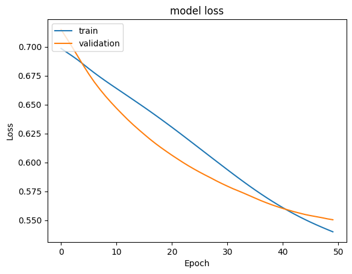

```python
#Plotting Train Loss vs Validation Loss
plt.plot(history_3.history['loss'])
plt.plot(history_3.history['val_loss'])
plt.title('model loss')
plt.ylabel('Loss')
plt.xlabel('Epoch')
plt.legend(['train', 'validation'], loc='upper left')
plt.show()
```

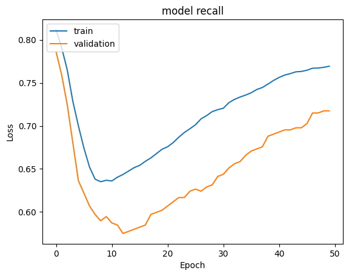

```python
#Plotting Train recall vs Validation recall
plt.plot(history_3.history['recall'])
plt.plot(history_3.history['val_recall'])
plt.title('model recall')
plt.ylabel('Loss')
plt.xlabel('Epoch')
plt.legend(['train', 'validation'], loc='upper left')
plt.show()
```

```python
y_train_pred = model_3.predict(X_train_smote)
#Predicting the results using 0.5 as the threshold
y_train_pred = (y_train_pred > 0.5)
y_train_pred
```

```
299/299 ━━━━━━━━━━━━━━━━━━━━ 0s 1ms/step
```

```
array([[ True],
       [ True],
       [ True],
       ...,
       [ True],
       [False],
       [ True]])
```

```python
y_val_pred = model_3.predict(X_val)
#Predicting the results using 0.5 as the threshold
y_val_pred = (y_val_pred > 0.5)
y_val_pred
```

```
63/63 ━━━━━━━━━━━━━━━━━━━━ 0s 1ms/step
```

```
array([[False],
       [False],
       [ True],
       ...,
       [False],
       [False],
       [ True]])
```

```python
model_name = "NN with SMOTE & SGD"

train_metric_df.loc[model_name] = recall_score(y_train_smote,y_train_pred)
valid_metric_df.loc[model_name] = recall_score(y_val,y_val_pred)
```

**Classification Report**

```python
cr=classification_report(y_train_smote,y_train_pred)
print(cr)
```

```
              precision    recall  f1-score   support

         0.0       0.76      0.71      0.73      4777
         1.0       0.73      0.77      0.75      4777

    accuracy                           0.74      9554
   macro avg       0.74      0.74      0.74      9554
weighted avg       0.74      0.74      0.74      9554
```

```python
cr=classification_report(y_val,y_val_pred)
print(cr)
```

```
              precision    recall  f1-score   support

         0.0       0.91      0.71      0.80      1593
         1.0       0.39      0.72      0.51       407

    accuracy                           0.71      2000
   macro avg       0.65      0.72      0.65      2000
weighted avg       0.80      0.71      0.74      2000
```

**Confusion matrix**

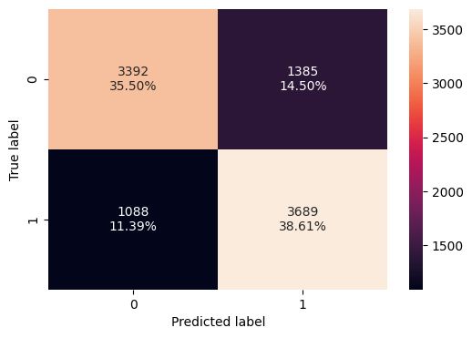

```python
#Calculating the confusion matrix
make_confusion_matrix(y_train_smote, y_train_pred)
```

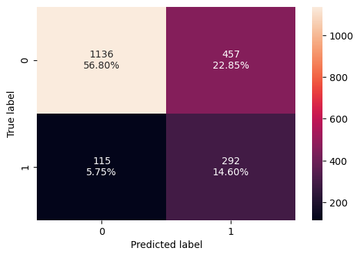

```python
#Calculating the confusion matrix

make_confusion_matrix(y_val,y_val_pred)
```

**Observations**

- Major improvement of Recall score on validation set.
- SMOTE has helped overcome the imbalance in data. Due to which model is now behaving more generically.
- Recall score across training and validation set is almost same. So model is behaving in a genaralized way.
- Loss also reduced smoothly.

### Neural Network with Balanced Data (by applying SMOTE) and Adam Optimizer

```python
backend.clear_session()
#Fixing the seed for random number generators so that we can ensure we receive the same output everytime
np.random.seed(2)
random.seed(2)
tf.random.set_seed(2)
```

```python
#Initializing the model
model_4 = Sequential()
model_4.add(Dense(32, activation='relu', input_dim = X_train_smote.shape[1]))
model_4.add(Dense(16, activation='relu'))
model_4.add(Dense(8, activation='relu'))
model_4.add(Dense(1, activation = 'sigmoid'))
```

```python
model_4.summary()
```

```
Model: "sequential"
```

```
┏━━━━━━━━━━━━━━━━━━━━━━━━━━━━━━━━━━━━━━┳━━━━━━━━━━━━━━━━━━━━━━━━━━━━━┳━━━━━━━━━━━━━━━━━┓
┃ Layer (type)                         ┃ Output Shape                ┃         Param # ┃
┡━━━━━━━━━━━━━━━━━━━━━━━━━━━━━━━━━━━━━━╇━━━━━━━━━━━━━━━━━━━━━━━━━━━━━╇━━━━━━━━━━━━━━━━━┩
│ dense (Dense)                        │ (None, 32)                  │             384 │
├──────────────────────────────────────┼─────────────────────────────┼─────────────────┤
│ dense_1 (Dense)                      │ (None, 16)                  │             528 │
├──────────────────────────────────────┼─────────────────────────────┼─────────────────┤
│ dense_2 (Dense)                      │ (None, 8)                   │             136 │
├──────────────────────────────────────┼─────────────────────────────┼─────────────────┤
│ dense_3 (Dense)                      │ (None, 1)                   │               9 │
└──────────────────────────────────────┴─────────────────────────────┴─────────────────┘
```

```
 Total params: 1,057 (4.13 KB)
```

```
 Trainable params: 1,057 (4.13 KB)
```

```
 Non-trainable params: 0 (0.00 B)
```

```python
optimizer = tf.keras.optimizers.Adam()
```

```python
metric = keras.metrics.Recall()
```

```python
model_4.compile(loss='binary_crossentropy',optimizer=optimizer,metrics=[metric])
```

```python
model_4.summary()
```

```
Model: "sequential"
```

```
┏━━━━━━━━━━━━━━━━━━━━━━━━━━━━━━━━━━━━━━┳━━━━━━━━━━━━━━━━━━━━━━━━━━━━━┳━━━━━━━━━━━━━━━━━┓
┃ Layer (type)                         ┃ Output Shape                ┃         Param # ┃
┡━━━━━━━━━━━━━━━━━━━━━━━━━━━━━━━━━━━━━━╇━━━━━━━━━━━━━━━━━━━━━━━━━━━━━╇━━━━━━━━━━━━━━━━━┩
│ dense (Dense)                        │ (None, 32)                  │             384 │
├──────────────────────────────────────┼─────────────────────────────┼─────────────────┤
│ dense_1 (Dense)                      │ (None, 16)                  │             528 │
├──────────────────────────────────────┼─────────────────────────────┼─────────────────┤
│ dense_2 (Dense)                      │ (None, 8)                   │             136 │
├──────────────────────────────────────┼─────────────────────────────┼─────────────────┤
│ dense_3 (Dense)                      │ (None, 1)                   │               9 │
└──────────────────────────────────────┴─────────────────────────────┴─────────────────┘
```

```
 Total params: 1,057 (4.13 KB)
```

```
 Trainable params: 1,057 (4.13 KB)
```

```
 Non-trainable params: 0 (0.00 B)
```

```python
#Fitting the ANN

history_4 = model_4.fit(
    X_train_smote,y_train_smote,
    batch_size=32,
    epochs=25,
    verbose=1,
    validation_data = (X_val,y_val)
)
```

```
299/299 ━━━━━━━━━━━━━━━━━━━━ 2s 8ms/step - loss: 0.3409 - recall: 0.8518 - val_loss: 0.4921 - val_recall: 0.7052
299/299 ━━━━━━━━━━━━━━━━━━━━ 2s 4ms/step - loss: 0.3395 - recall: 0.8543 - val_loss: 0.4910 - val_recall: 0.7027
299/299 ━━━━━━━━━━━━━━━━━━━━ 2s 2ms/step - loss: 0.3383 - recall: 0.8547 - val_loss: 0.4922 - val_recall: 0.7027
299/299 ━━━━━━━━━━━━━━━━━━━━ 1s 3ms/step - loss: 0.3368 - recall: 0.8544 - val_loss: 0.4925 - val_recall: 0.6904
299/299 ━━━━━━━━━━━━━━━━━━━━ 1s 3ms/step - loss: 0.3355 - recall: 0.8570 - val_loss: 0.4928 - val_recall: 0.6978
299/299 ━━━━━━━━━━━━━━━━━━━━ 1s 3ms/step - loss: 0.3333 - recall: 0.8597 - val_loss: 0.4911 - val_recall: 0.6953
299/299 ━━━━━━━━━━━━━━━━━━━━ 1s 3ms/step - loss: 0.3319 - recall: 0.8600 - val_loss: 0.4911 - val_recall: 0.6978
299/299 ━━━━━━━━━━━━━━━━━━━━ 1s 3ms/step - loss: 0.3303 - recall: 0.8609 - val_loss: 0.4881 - val_recall: 0.6978
299/299 ━━━━━━━━━━━━━━━━━━━━ 1s 5ms/step - loss: 0.3289 - recall: 0.8630 - val_loss: 0.4885 - val_recall: 0.6978
299/299 ━━━━━━━━━━━━━━━━━━━━ 2s 4ms/step - loss: 0.3276 - recall: 0.8625 - val_loss: 0.4870 - val_recall: 0.6978
299/299 ━━━━━━━━━━━━━━━━━━━━ 1s 3ms/step - loss: 0.3264 - recall: 0.8639 - val_loss: 0.4870 - val_recall: 0.6978
299/299 ━━━━━━━━━━━━━━━━━━━━ 1s 2ms/step - loss: 0.3250 - recall: 0.8656 - val_loss: 0.4874 - val_recall: 0.7002
299/299 ━━━━━━━━━━━━━━━━━━━━ 1s 3ms/step - loss: 0.3242 - recall: 0.8641 - val_loss: 0.4884 - val_recall: 0.7002
299/299 ━━━━━━━━━━━━━━━━━━━━ 1s 3ms/step - loss: 0.3231 - recall: 0.8645 - val_loss: 0.4891 - val_recall: 0.7002
299/299 ━━━━━━━━━━━━━━━━━━━━ 1s 3ms/step - loss: 0.3221 - recall: 0.8648 - val_loss: 0.4892 - val_recall: 0.7002
299/299 ━━━━━━━━━━━━━━━━━━━━ 1s 3ms/step - loss: 0.3210 - recall: 0.8668 - val_loss: 0.4901 - val_recall: 0.7002
299/299 ━━━━━━━━━━━━━━━━━━━━ 1s 3ms/step - loss: 0.3200 - recall: 0.8668 - val_loss: 0.4931 - val_recall: 0.7027
299/299 ━━━━━━━━━━━━━━━━━━━━ 1s 3ms/step - loss: 0.3185 - recall: 0.8689 - val_loss: 0.4929 - val_recall: 0.7052
299/299 ━━━━━━━━━━━━━━━━━━━━ 1s 3ms/step - loss: 0.3174 - recall: 0.8677 - val_loss: 0.4959 - val_recall: 0.7076
299/299 ━━━━━━━━━━━━━━━━━━━━ 2s 4ms/step - loss: 0.3164 - recall: 0.8672 - val_loss: 0.4962 - val_recall: 0.7101
299/299 ━━━━━━━━━━━━━━━━━━━━ 2s 3ms/step - loss: 0.3153 - recall: 0.8693 - val_loss: 0.4965 - val_recall: 0.7027
299/299 ━━━━━━━━━━━━━━━━━━━━ 1s 3ms/step - loss: 0.3145 - recall: 0.8689 - val_loss: 0.5007 - val_recall: 0.7125
299/299 ━━━━━━━━━━━━━━━━━━━━ 1s 3ms/step - loss: 0.3138 - recall: 0.8685 - val_loss: 0.4985 - val_recall: 0.7101
299/299 ━━━━━━━━━━━━━━━━━━━━ 1s 3ms/step - loss: 0.3126 - recall: 0.8695 - val_loss: 0.5027 - val_recall: 0.7150
299/299 ━━━━━━━━━━━━━━━━━━━━ 1s 3ms/step - loss: 0.3120 - recall: 0.8685 - val_loss: 0.5028 - val_recall: 0.7101
```

**Loss function**

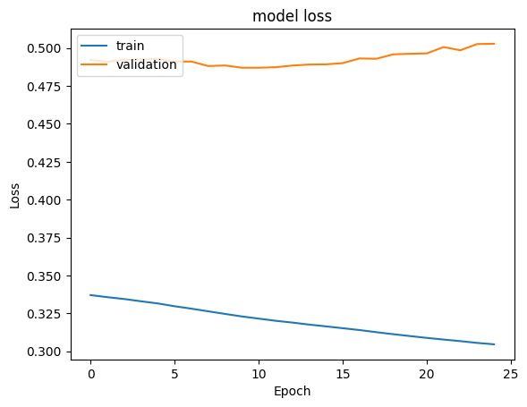

```python
#Plotting Train Loss vs Validation Loss
plt.plot(history_4.history['loss'])
plt.plot(history_4.history['val_loss'])
plt.title('model loss')
plt.ylabel('Loss')
plt.xlabel('Epoch')
plt.legend(['train', 'validation'], loc='upper left')
plt.show()
```

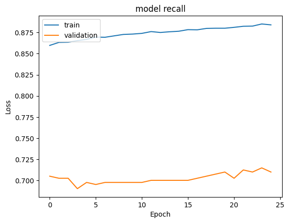

```python
#Plotting Train recall vs Validation recall
plt.plot(history_4.history['recall'])
plt.plot(history_4.history['val_recall'])
plt.title('model recall')
plt.ylabel('Loss')
plt.xlabel('Epoch')
plt.legend(['train', 'validation'], loc='upper left')
plt.show()
```

```python
y_train_pred = model_4.predict(X_train_smote)
#Predicting the results using 0.5 as the threshold
y_train_pred = (y_train_pred > 0.5)
y_train_pred
```

```
299/299 ━━━━━━━━━━━━━━━━━━━━ 0s 1ms/step
```

```
array([[ True],
       [ True],
       [ True],
       ...,
       [ True],
       [False],
       [ True]])
```

```python
y_val_pred = model_4.predict(X_val)
#Predicting the results using 0.5 as the threshold
y_val_pred = (y_val_pred > 0.5)
y_val_pred
```

```
63/63 ━━━━━━━━━━━━━━━━━━━━ 0s 1ms/step
```

```
array([[False],
       [False],
       [ True],
       ...,
       [False],
       [False],
       [False]])
```

```python
model_name = "NN with SMOTE & Adam"

train_metric_df.loc[model_name] = recall_score(y_train_smote,y_train_pred)
valid_metric_df.loc[model_name] = recall_score(y_val,y_val_pred)
```

**Classification report**

```python
cr=classification_report(y_train_smote,y_train_pred)
print(cr)
```

```
              precision    recall  f1-score   support

         0.0       0.91      0.83      0.87      4777
         1.0       0.84      0.92      0.88      4777

    accuracy                           0.87      9554
   macro avg       0.88      0.87      0.87      9554
weighted avg       0.88      0.87      0.87      9554
```

```python
cr=classification_report(y_val,y_val_pred) ## Complete the code to check the model's performance on the validation set
print(cr)
```

```
              precision    recall  f1-score   support

         0.0       0.92      0.80      0.86      1593
         1.0       0.48      0.71      0.57       407

    accuracy                           0.78      2000
   macro avg       0.70      0.76      0.71      2000
weighted avg       0.83      0.78      0.80      2000
```

**Confusion matrix**

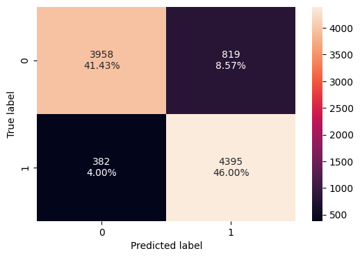

```python
#Calculating the confusion matrix
make_confusion_matrix(y_train_smote, y_train_pred)
```

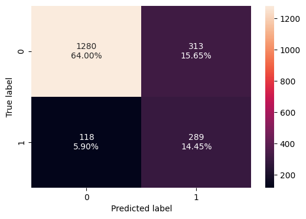

```python
#Calculating the confusion matrix
make_confusion_matrix(y_val,y_val_pred)  ## Complete the code to check the model's performance on the validation set
```

**Observations**

### Neural Network with Balanced Data (by applying SMOTE), Adam Optimizer, and Dropout

```python
backend.clear_session()
#Fixing the seed for random number generators so that we can ensure we receive the same output everytime
np.random.seed(2)
random.seed(2)
tf.random.set_seed(2)
```

```python
model_5 = Sequential()
model_5.add(Dense(32,activation='relu',input_dim = X_train_smote.shape[1]))
model_5.add(Dropout(0.2))
model_5.add(Dense(16,activation='relu'))
model_5.add(Dropout(0.1))
model_5.add(Dense(8,activation='relu'))
model_5.add(Dense(1, activation = 'sigmoid'))
```

```python
#using Adam as the optimizer.
optimizer = tf.keras.optimizers.Adam()
```

```python
metric = keras.metrics.Recall()
```

```python
# model with binary cross entropy as loss function and recall as the metric
model_5.compile(loss='binary_crossentropy',optimizer=optimizer,metrics=[metric])
```

```python
model_5.summary()
```

```
Model: "sequential"
```

```
┏━━━━━━━━━━━━━━━━━━━━━━━━━━━━━━━━━━━━━━┳━━━━━━━━━━━━━━━━━━━━━━━━━━━━━┳━━━━━━━━━━━━━━━━━┓
┃ Layer (type)                         ┃ Output Shape                ┃         Param # ┃
┡━━━━━━━━━━━━━━━━━━━━━━━━━━━━━━━━━━━━━━╇━━━━━━━━━━━━━━━━━━━━━━━━━━━━━╇━━━━━━━━━━━━━━━━━┩
│ dense (Dense)                        │ (None, 32)                  │             384 │
├──────────────────────────────────────┼─────────────────────────────┼─────────────────┤
│ dropout (Dropout)                    │ (None, 32)                  │               0 │
├──────────────────────────────────────┼─────────────────────────────┼─────────────────┤
│ dense_1 (Dense)                      │ (None, 16)                  │             528 │
├──────────────────────────────────────┼─────────────────────────────┼─────────────────┤
│ dropout_1 (Dropout)                  │ (None, 16)                  │               0 │
├──────────────────────────────────────┼─────────────────────────────┼─────────────────┤
│ dense_2 (Dense)                      │ (None, 8)                   │             136 │
├──────────────────────────────────────┼─────────────────────────────┼─────────────────┤
│ dense_3 (Dense)                      │ (None, 1)                   │               9 │
└──────────────────────────────────────┴─────────────────────────────┴─────────────────┘
```

```
 Total params: 1,057 (4.13 KB)
```

```
 Trainable params: 1,057 (4.13 KB)
```

```
 Non-trainable params: 0 (0.00 B)
```

```python
history_5 = model_5.fit(
    X_train_smote,y_train_smote,
    batch_size=32, ## Complete the code to specify the batch size to use
    epochs=100, ## Complete the code to specify the number of epochs
    verbose=1,
    validation_data = (X_val,y_val))
```

```
299/299 ━━━━━━━━━━━━━━━━━━━━ 3s 4ms/step - loss: 0.6308 - recall: 0.6354 - val_loss: 0.5605 - val_recall: 0.7813
299/299 ━━━━━━━━━━━━━━━━━━━━ 1s 3ms/step - loss: 0.5336 - recall: 0.7657 - val_loss: 0.5260 - val_recall: 0.7764
299/299 ━━━━━━━━━━━━━━━━━━━━ 1s 3ms/step - loss: 0.4996 - recall: 0.7702 - val_loss: 0.5047 - val_recall: 0.7740
299/299 ━━━━━━━━━━━━━━━━━━━━ 1s 3ms/step - loss: 0.4869 - recall: 0.7650 - val_loss: 0.5016 - val_recall: 0.7641
299/299 ━━━━━━━━━━━━━━━━━━━━ 1s 3ms/step - loss: 0.4751 - recall: 0.7647 - val_loss: 0.4972 - val_recall: 0.7568
299/299 ━━━━━━━━━━━━━━━━━━━━ 1s 3ms/step - loss: 0.4699 - recall: 0.7606 - val_loss: 0.4922 - val_recall: 0.7494
299/299 ━━━━━━━━━━━━━━━━━━━━ 1s 3ms/step - loss: 0.4631 - recall: 0.7666 - val_loss: 0.4954 - val_recall: 0.7518
299/299 ━━━━━━━━━━━━━━━━━━━━ 1s 3ms/step - loss: 0.4598 - recall: 0.7715 - val_loss: 0.4924 - val_recall: 0.7666
299/299 ━━━━━━━━━━━━━━━━━━━━ 2s 5ms/step - loss: 0.4533 - recall: 0.7753 - val_loss: 0.4926 - val_recall: 0.7789
299/299 ━━━━━━━━━━━━━━━━━━━━ 2s 4ms/step - loss: 0.4545 - recall: 0.7878 - val_loss: 0.4783 - val_recall: 0.7396
299/299 ━━━━━━━━━━━━━━━━━━━━ 1s 3ms/step - loss: 0.4498 - recall: 0.7747 - val_loss: 0.4792 - val_recall: 0.7518
299/299 ━━━━━━━━━━━━━━━━━━━━ 1s 3ms/step - loss: 0.4519 - recall: 0.7865 - val_loss: 0.4761 - val_recall: 0.7420
299/299 ━━━━━━━━━━━━━━━━━━━━ 1s 3ms/step - loss: 0.4398 - recall: 0.7797 - val_loss: 0.4826 - val_recall: 0.7568
299/299 ━━━━━━━━━━━━━━━━━━━━ 1s 3ms/step - loss: 0.4433 - recall: 0.7824 - val_loss: 0.4772 - val_recall: 0.7494
299/299 ━━━━━━━━━━━━━━━━━━━━ 1s 3ms/step - loss: 0.4449 - recall: 0.7848 - val_loss: 0.4831 - val_recall: 0.7666
299/299 ━━━━━━━━━━━━━━━━━━━━ 1s 3ms/step - loss: 0.4407 - recall: 0.7913 - val_loss: 0.4799 - val_recall: 0.7690
299/299 ━━━━━━━━━━━━━━━━━━━━ 1s 3ms/step - loss: 0.4398 - recall: 0.7938 - val_loss: 0.4811 - val_recall: 0.7592
299/299 ━━━━━━━━━━━━━━━━━━━━ 1s 3ms/step - loss: 0.4328 - recall: 0.7912 - val_loss: 0.4828 - val_recall: 0.7518
299/299 ━━━━━━━━━━━━━━━━━━━━ 1s 3ms/step - loss: 0.4333 - recall: 0.7917 - val_loss: 0.4711 - val_recall: 0.7445
299/299 ━━━━━━━━━━━━━━━━━━━━ 2s 5ms/step - loss: 0.4404 - recall: 0.7871 - val_loss: 0.4773 - val_recall: 0.7666
299/299 ━━━━━━━━━━━━━━━━━━━━ 2s 3ms/step - loss: 0.4266 - recall: 0.7986 - val_loss: 0.4696 - val_recall: 0.7543
299/299 ━━━━━━━━━━━━━━━━━━━━ 1s 3ms/step - loss: 0.4354 - recall: 0.7936 - val_loss: 0.4884 - val_recall: 0.7764
299/299 ━━━━━━━━━━━━━━━━━━━━ 1s 3ms/step - loss: 0.4251 - recall: 0.8044 - val_loss: 0.4693 - val_recall: 0.7543
299/299 ━━━━━━━━━━━━━━━━━━━━ 1s 3ms/step - loss: 0.4219 - recall: 0.8040 - val_loss: 0.4765 - val_recall: 0.7518
299/299 ━━━━━━━━━━━━━━━━━━━━ 1s 3ms/step - loss: 0.4268 - recall: 0.7983 - val_loss: 0.4705 - val_recall: 0.7617
299/299 ━━━━━━━━━━━━━━━━━━━━ 1s 3ms/step - loss: 0.4261 - recall: 0.8050 - val_loss: 0.4787 - val_recall: 0.7641
299/299 ━━━━━━━━━━━━━━━━━━━━ 1s 3ms/step - loss: 0.4246 - recall: 0.8041 - val_loss: 0.4718 - val_recall: 0.7592
299/299 ━━━━━━━━━━━━━━━━━━━━ 1s 3ms/step - loss: 0.4203 - recall: 0.8151 - val_loss: 0.4757 - val_recall: 0.7543
299/299 ━━━━━━━━━━━━━━━━━━━━ 2s 5ms/step - loss: 0.4258 - recall: 0.8073 - val_loss: 0.4709 - val_recall: 0.7518
299/299 ━━━━━━━━━━━━━━━━━━━━ 2s 3ms/step - loss: 0.4234 - recall: 0.8062 - val_loss: 0.4668 - val_recall: 0.7543
299/299 ━━━━━━━━━━━━━━━━━━━━ 1s 3ms/step - loss: 0.4195 - recall: 0.8046 - val_loss: 0.4738 - val_recall: 0.7592
299/299 ━━━━━━━━━━━━━━━━━━━━ 1s 3ms/step - loss: 0.4182 - recall: 0.8105 - val_loss: 0.4591 - val_recall: 0.7420
299/299 ━━━━━━━━━━━━━━━━━━━━ 1s 3ms/step - loss: 0.4129 - recall: 0.8102 - val_loss: 0.4669 - val_recall: 0.7568
299/299 ━━━━━━━━━━━━━━━━━━━━ 1s 3ms/step - loss: 0.4159 - recall: 0.8094 - val_loss: 0.4779 - val_recall: 0.7617
299/299 ━━━━━━━━━━━━━━━━━━━━ 1s 3ms/step - loss: 0.4140 - recall: 0.8210 - val_loss: 0.4669 - val_recall: 0.7568
299/299 ━━━━━━━━━━━━━━━━━━━━ 1s 3ms/step - loss: 0.4153 - recall: 0.8123 - val_loss: 0.4686 - val_recall: 0.7469
299/299 ━━━━━━━━━━━━━━━━━━━━ 1s 3ms/step - loss: 0.4137 - recall: 0.8120 - val_loss: 0.4671 - val_recall: 0.7371
299/299 ━━━━━━━━━━━━━━━━━━━━ 1s 3ms/step - loss: 0.4104 - recall: 0.8144 - val_loss: 0.4731 - val_recall: 0.7469
299/299 ━━━━━━━━━━━━━━━━━━━━ 1s 3ms/step - loss: 0.4154 - recall: 0.8125 - val_loss: 0.4658 - val_recall: 0.7322
299/299 ━━━━━━━━━━━━━━━━━━━━ 2s 4ms/step - loss: 0.4112 - recall: 0.8206 - val_loss: 0.4753 - val_recall: 0.7543
```

[output cut: 45 more lines]

```
299/299 ━━━━━━━━━━━━━━━━━━━━ 1s 3ms/step - loss: 0.3929 - recall: 0.8206 - val_loss: 0.4598 - val_recall: 0.7027
299/299 ━━━━━━━━━━━━━━━━━━━━ 1s 3ms/step - loss: 0.3964 - recall: 0.8296 - val_loss: 0.4638 - val_recall: 0.7248
299/299 ━━━━━━━━━━━━━━━━━━━━ 1s 3ms/step - loss: 0.3933 - recall: 0.8298 - val_loss: 0.4630 - val_recall: 0.7199
299/299 ━━━━━━━━━━━━━━━━━━━━ 1s 3ms/step - loss: 0.3875 - recall: 0.8353 - val_loss: 0.4557 - val_recall: 0.7027
299/299 ━━━━━━━━━━━━━━━━━━━━ 1s 3ms/step - loss: 0.3930 - recall: 0.8288 - val_loss: 0.4527 - val_recall: 0.7052
299/299 ━━━━━━━━━━━━━━━━━━━━ 2s 5ms/step - loss: 0.3952 - recall: 0.8235 - val_loss: 0.4657 - val_recall: 0.7273
299/299 ━━━━━━━━━━━━━━━━━━━━ 2s 3ms/step - loss: 0.3887 - recall: 0.8304 - val_loss: 0.4632 - val_recall: 0.7199
299/299 ━━━━━━━━━━━━━━━━━━━━ 1s 3ms/step - loss: 0.3938 - recall: 0.8376 - val_loss: 0.4665 - val_recall: 0.7396
299/299 ━━━━━━━━━━━━━━━━━━━━ 1s 3ms/step - loss: 0.3897 - recall: 0.8366 - val_loss: 0.4571 - val_recall: 0.7125
299/299 ━━━━━━━━━━━━━━━━━━━━ 1s 3ms/step - loss: 0.3812 - recall: 0.8426 - val_loss: 0.4641 - val_recall: 0.7248
299/299 ━━━━━━━━━━━━━━━━━━━━ 1s 3ms/step - loss: 0.3918 - recall: 0.8267 - val_loss: 0.4637 - val_recall: 0.7125
299/299 ━━━━━━━━━━━━━━━━━━━━ 1s 3ms/step - loss: 0.3885 - recall: 0.8314 - val_loss: 0.4605 - val_recall: 0.7224
299/299 ━━━━━━━━━━━━━━━━━━━━ 1s 3ms/step - loss: 0.3874 - recall: 0.8366 - val_loss: 0.4613 - val_recall: 0.7150
299/299 ━━━━━━━━━━━━━━━━━━━━ 1s 3ms/step - loss: 0.3900 - recall: 0.8318 - val_loss: 0.4665 - val_recall: 0.7224
299/299 ━━━━━━━━━━━━━━━━━━━━ 1s 3ms/step - loss: 0.3863 - recall: 0.8365 - val_loss: 0.4631 - val_recall: 0.7174
```

**Loss function**

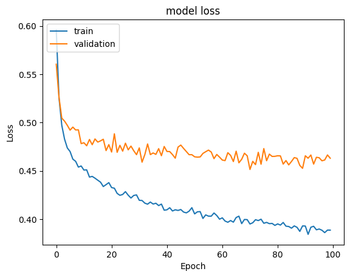

```python
#Plotting Train Loss vs Validation Loss
plt.plot(history_5.history['loss'])
plt.plot(history_5.history['val_loss'])
plt.title('model loss')
plt.ylabel('Loss')
plt.xlabel('Epoch')
plt.legend(['train', 'validation'], loc='upper left')
plt.show()
```

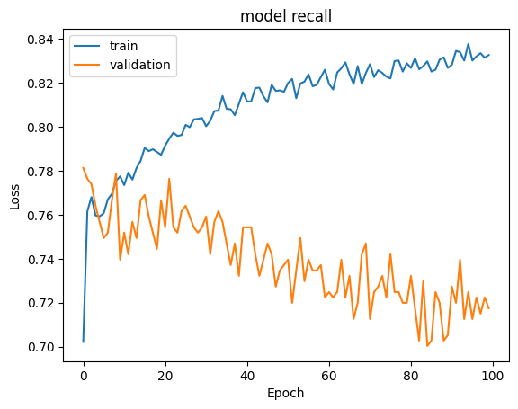

```python
#Plotting Train recall vs Validation recall
plt.plot(history_5.history['recall'])
plt.plot(history_5.history['val_recall'])
plt.title('model recall')
plt.ylabel('Loss')
plt.xlabel('Epoch')
plt.legend(['train', 'validation'], loc='upper left')
plt.show()
```

```python
y_train_pred = model_5.predict(X_train_smote)
#Predicting the results using 0.5 as the threshold
y_train_pred = (y_train_pred > 0.5)
y_train_pred
```

```
299/299 ━━━━━━━━━━━━━━━━━━━━ 0s 1ms/step
```

```
array([[False],
       [ True],
       [ True],
       ...,
       [ True],
       [False],
       [ True]])
```

```python
y_val_pred = model_5.predict(X_val)
#Predicting the results using 0.5 as the threshold
y_val_pred = (y_val_pred > 0.5)
y_val_pred
```

```
63/63 ━━━━━━━━━━━━━━━━━━━━ 0s 1ms/step
```

```
array([[False],
       [False],
       [ True],
       ...,
       [False],
       [False],
       [ True]])
```

```python
model_name = "NN with SMOTE,Adam & Dropout"

train_metric_df.loc[model_name] = recall_score(y_train_smote,y_train_pred)
valid_metric_df.loc[model_name] = recall_score(y_val,y_val_pred)
```

**Classification report**

```python
cr=classification_report(y_train_smote,y_train_pred)
print(cr)
```

```
              precision    recall  f1-score   support

         0.0       0.86      0.82      0.84      4777
         1.0       0.83      0.87      0.85      4777

    accuracy                           0.85      9554
   macro avg       0.85      0.85      0.85      9554
weighted avg       0.85      0.85      0.85      9554
```

```python
#classification report
cr=classification_report(y_val,y_val_pred)
print(cr)
```

```
              precision    recall  f1-score   support

         0.0       0.92      0.79      0.85      1593
         1.0       0.46      0.72      0.56       407

    accuracy                           0.77      2000
   macro avg       0.69      0.75      0.70      2000
weighted avg       0.82      0.77      0.79      2000
```

**Confusion matrix**

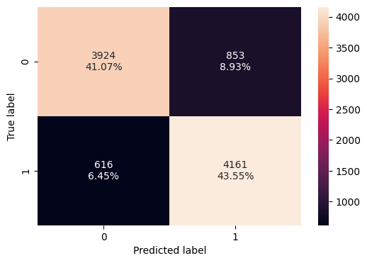

```python
#Calculating the confusion matrix
make_confusion_matrix(y_train_smote, y_train_pred)
```

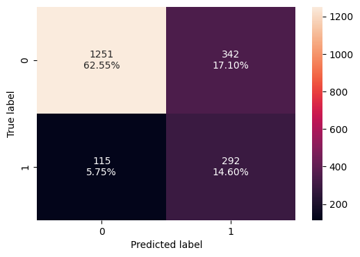

```python
#Calculating the confusion matrix
make_confusion_matrix(y_val,y_val_pred)
```

## Model Performance Comparison and Final Model Selection

```python
print("Training performance comparison")
train_metric_df
```

```
Training performance comparison
```

|  | recall |
| --- | --- |
| NN with SGD | 0.134096 |
| NN with Adam | 0.580540 |
| NN with Adam & Dropout | 0.551922 |
| NN with SMOTE & SGD | 0.772242 |
| NN with SMOTE & Adam | 0.920033 |
| NN with SMOTE,Adam & Dropout | 0.871049 |

```python
print("Validation set performance comparison")
valid_metric_df
```

```
Validation set performance comparison
```

|  | recall |
| --- | --- |
| NN with SGD | 0.117936 |
| NN with Adam | 0.469287 |
| NN with Adam & Dropout | 0.481572 |
| NN with SMOTE & SGD | 0.717445 |
| NN with SMOTE & Adam | 0.710074 |
| NN with SMOTE,Adam & Dropout | 0.717445 |

Since the model optimized as SGD and trained with SMOTE data is behaving consistently across training and validation data , so recommending to use this model. As this model is expected to behave consistently on unseen data.

```python
train_metric_df - valid_metric_df
```

|  | recall |
| --- | --- |
| NN with SGD | 0.016160 |
| NN with Adam | 0.111252 |
| NN with Adam & Dropout | 0.070349 |
| NN with SMOTE & SGD | 0.054797 |
| NN with SMOTE & Adam | 0.209960 |
| NN with SMOTE,Adam & Dropout | 0.153604 |

```python
#selecting model_3 as it is behaving consistently across test and validation data
y_test_pred = model_3.predict(X_test)
y_test_pred = (y_test_pred > 0.5)
print(y_test_pred)
```

```
63/63 ━━━━━━━━━━━━━━━━━━━━ 0s 4ms/step
[[False]
 [ True]
 [False]
 ...
 [ True]
 [False]
 [False]]
```

```python
#lets print classification report
cr=classification_report(y_test,y_test_pred)
print(cr)
```

```
              precision    recall  f1-score   support

         0.0       0.92      0.70      0.80      1593
         1.0       0.39      0.76      0.52       407

    accuracy                           0.71      2000
   macro avg       0.66      0.73      0.66      2000
weighted avg       0.81      0.71      0.74      2000
```

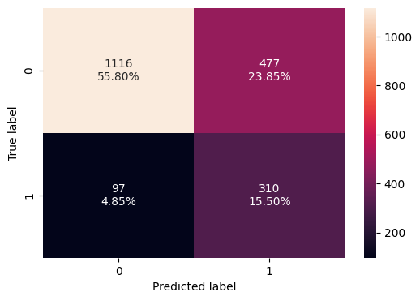

```python
#Calculating the confusion matrix
make_confusion_matrix(y_test,y_test_pred)
```

**Observation**

## Actionable Insights and Business Recommendations

- Bank can use the neural network with Balanced Data (by applying SMOTE) and SGD Optimizer as its model to predict customer churn. If the model decides that a customer may churn. Then special attention needs to be given to those customers.
- 75% of customers who have churned had a longer tenure with the bank compared to 75% of non-churned customers. This warrants investigation, as the bank is losing long-term customers.
- Active members have a lower likelihood of churning. The bank should prioritize engaging inactive members and encouraging them to use its products more.
- Germany has the highest percentage of churned customers. The bank should focus on this region and conduct a thorough investigation to understand the underlying causes.
- There are 3,500 customers (approximately one-third) with a zero balance. This issue requires deeper analysis, and the bank should consider offering incentives to encourage these customers to invest more.

Power Ahead